# Scrub Oak GLMM all groups

Kathleen Stutzman

2024-01-05

Set working directory

```r
knitr::opts_knit$set(root.dir = '/Users/user/Desktop/Data/Regen_RProj/')
```

## Introduction:

This script was written to be an easier read than the straight R script

# Scrub Oak Small Seedling GLMM Code:

This code chunk uses all the same steps to import small seedling data before refining it to Scrub Oak (QUIL, QUPR). These are the same steps as in the PIRI script and are hidden below in one chunk

Source small seedling data:

```r
source("Scripts/SS_Import.R")
```

Refine to just scrub oak:

```r
ss_SO <- ss_merge %>%
  filter(Species_Groups == "Shrub Oak") %>%
  arrange(Treat_Type)

# now to make the explanatory variables factors
ss_SO$Treat_Type = factor(ss_SO$Treat_Type,
                            levels = unique(ss_SO $Treat_Type))
ss_SO$Region = factor(ss_SO$Region,
                        levels = unique(ss_SO$Region))
ss_SO$Site = factor(ss_SO$Site,
                      levels = unique(ss_SO$Site))
```

Import time since data and add it to the PIRI dataset

```r
time_since <- read_csv("CleanData/Treat_Year_Data.csv")
ss_SO1 <- merge(ss_SO, time_since, by = "Site")
#log transform time from treatment data
ss_SO1$l.TFT <- log(ss_SO1$Time_from_Treat)
```

Run the ‘Add_BA’ script and merge with dataset:

```r
source("Scripts/Add_BA.R")
```

```r
# merge with ls dataset -------------------
ss_SO2 <- merge(ss_SO1, prism_BA, by = 'Plot_No')
```

Run ‘Ground_Data.R’ script and add it to PIRI dataset:

```r
source("Scripts/Ground_Data.R")

# merge with ls dataset -------------------
ss_SO.all <- merge(ss_SO2, ground3, by = "Plot_No")

rm(ss_SO1,
   ss_SO2)
```

Hidden below are early models that used the poisson distribution. All are underdispersed:

As the above models were under dispersed, I then moved to trying the generalized Poisson and COM-poisson distributions. COM-poisson still resulted in under dispersion, so generalized Poisson was the best distribution:

```r
#Starting with the most variables
so.ss_gp1 <- glmmTMB(Total~Treat_Type + avgLD_l + l.BA_HA + l.BA_piri + l.Mineral + (1|Site/Plot_No) + offset(l.TFT),
                     data = ss_SO.all,
                     family = genpois)
summary(so.ss_gp1) #AIC is 1862.7


# using DHARMa package to check model fit -------------------
so.ss1_sr <- simulateResiduals(fittedModel = so.ss_gp1, n = 1000, plot = TRUE) #passes the test

testDispersion(so.ss1_sr)
#alternative = 'less') #the model is underdispersed
testOutliers(so.ss1_sr) #fine
testZeroInflation(so.ss1_sr) #fine

# some issues with residual quantiles. Going to drop items from the model and see what happens to the AIC, then re-test in DHARMa and see what happens to residual quantiles

so.ss_gp2 <- glmmTMB(Total~Treat_Type + avgLD_l + l.BA_HA + l.BA_piri + l.Mineral + (1|Site/Plot_No),
                     data = ss_SO.all,
                     family = genpois)
AIC(so.ss_gp2) #1850

so.ss_gp3 <- glmmTMB(Total~Treat_Type + avgLD_l + l.BA_HA + l.Mineral + (1|Site/Plot_No),
                     data = ss_SO.all,
                     family = genpois)
AIC(so.ss_gp3) #1848.7

library(lmtest)
lrtest(so.ss_gp2, so.ss_gp3) # p value is 0.37

so.ss_gp4 <- glmmTMB(Total~Treat_Type + avgLD_l + l.BA_HA + (1|Site/Plot_No),
                     data = ss_SO.all,
                     family = genpois)
AIC(so.ss_gp4) #1847

lrtest(so.ss_gp3, so.ss_gp4) # p = .5

so.ss_gp5 <- glmmTMB(Total~Treat_Type + avgLD_l + (1|Site/Plot_No),
                     data = ss_SO.all,
                     family = genpois)
AIC(so.ss_gp5) #1845.1

so.ss_gp6 <- glmmTMB(Total~Treat_Type + (1|Site/Plot_No),
                     data = ss_SO.all,
                     family = genpois)
AIC(so.ss_gp6) #1845.8

lrtest(so.ss_gp5, so.ss_gp6) # p=.1, so not worth it to keep avgLD

so.ss6_sr <- simulateResiduals(fittedModel = so.ss_gp6, n = 1000, plot = TRUE) #passes the test

testDispersion(so.ss6_sr)
testDispersion(so.ss6_sr, alternative = 'less') # passes
testOutliers(so.ss6_sr) #fine
testZeroInflation(so.ss6_sr) #fine


#this was just to see if issues with quantile predicitios had been resolved
so.ss5_sr <- simulateResiduals(fittedModel = so.ss_gp5, n = 1000, plot = TRUE) #It had not; using the compois distro gets rid of the quantile prediction issues, but the model is under dispersed

testDispersion(so.ss5_sr) #passes
testOutliers(so.ss5_sr) #fine
testZeroInflation(so.ss5_sr) #fine

so.ss_cp7 <- glmmTMB(Total~Treat_Type + avgLD_l + (1|Site/Plot_No),
                     data = ss_SO.all,
                     family = compois)
AIC(so.ss_cp7) #1866.2; doesn't seem like a better fit but will look in DHARMa

so.ss7_sr <- simulateResiduals(fittedModel = so.ss_cp7, n = 1000, plot = TRUE) #gets rid of residual quantile issues

testDispersion(so.ss7_sr) # just barely passes
testDispersion(so.ss7_sr, alternative = 'less') #doesn't pass, model is still underdispersed
testDispersion(so.ss7_sr, alternative = 'greater')# passes
testOutliers(so.ss7_sr) #fine
testZeroInflation(so.ss7_sr) #fine


# trying best model with com pois distro
so.ss_cp8 <- glmmTMB(Total~Treat_Type + (1|Site/Plot_No),
                     data = ss_SO.all,
                     family = compois)
AIC(so.ss_cp8) #1865.9

so.ss8_sr <- simulateResiduals(fittedModel = so.ss_cp8, n = 1000, plot = TRUE)

testDispersion(so.ss8_sr) # just barely passes
testDispersion(so.ss8_sr, alternative = 'less') #doesn't pass, model is still underdispersed
testDispersion(so.ss8_sr, alternative = 'greater')# passes
testOutliers(so.ss8_sr) #fine
testZeroInflation(so.ss8_sr)




# this is the best model -------------------
so.ss_gp6 <- glmmTMB(Total~Treat_Type + (1|Site/Plot_No),
                     data = ss_SO.all,
                     family = genpois)
summary(so.ss_gp6)


rm(so.ss1_sr,
   so.ss5_sr,
   so.ss7_sr,
   so.ss8_sr,
   so.ss_cp8,
   so.ss_gp1,
   so.ss_gp2,
   so.ss_gp3,
   so.ss_gp4,
   so.ss_gp5,
   so.ss_gp7)
```

```r
# this is the best model -------------------
so.ss_gp6 <- glmmTMB(Total~Treat_Type + (1|Site/Plot_No),
                     data = ss_SO.all,
                     family = genpois)
summary(so.ss_gp6)
```

```
##  Family: genpois  ( log )
## Formula:          Total ~ Treat_Type + (1 | Site/Plot_No)
## Data: ss_SO.all
##
##      AIC      BIC   logLik deviance df.resid
##   1845.8   1879.5   -914.9   1829.8      490
##
## Random effects:
##
## Conditional model:
##  Groups       Name        Variance Std.Dev.
##  Plot_No:Site (Intercept) 0.3074   0.5544
##  Site         (Intercept) 0.5669   0.7529
## Number of obs: 498, groups:  Plot_No:Site, 498; Site, 47
##
## Dispersion parameter for genpois family (): 6.14
##
## Conditional model:
##                    Estimate Std. Error z value Pr(>|z|)
## (Intercept)          0.1781     0.2944   0.605   0.5451
## Treat_TypeFallRx     0.7584     0.3991   1.900   0.0574 .
## Treat_TypeHarvest   -0.7572     0.5123  -1.478   0.1394
## Treat_TypeMowRx      0.5676     0.3750   1.514   0.1301
## Treat_TypeSpringRx  -0.0106     0.4175  -0.025   0.9797
## ---
## Signif. codes:  0 '***' 0.001 '**' 0.01 '*' 0.05 '.' 0.1 ' ' 1
```

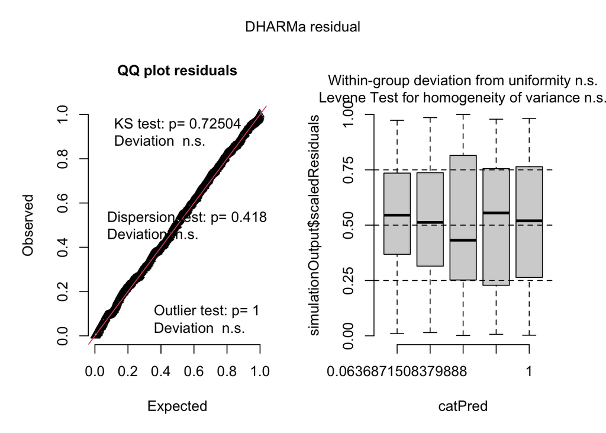

```r
so.ss6_sr <- simulateResiduals(fittedModel = so.ss_gp6, n = 1000, plot = TRUE) #passes the test
```